# TP5

La variable à régresser se situe à gauche, le ou les régresseurs à droite.

```r
donnees <- data.frame(varx = c(0, 0.2, 0.3, 0.6),
vary = c(1.01, 1.44, 1.55, 2.1))
donnees
```

| varx | vary |
| --- | --- |
| 0.0 | 1.01 |
| 0.2 | 1.44 |
| 0.3 | 1.55 |
| 0.6 | 2.10 |

Question 1

```r
lm=lm(vary~varx, data = donnees)
lm
```

```
Call:
lm(formula = vary ~ varx, data = donnees)

Coefficients:
(Intercept)         varx
      1.033        1.789
```

On trouve la régression suivante: vary=b*varx + a= 1.789*varx + 1.033

Question 2 Uilisation de plot et de abline

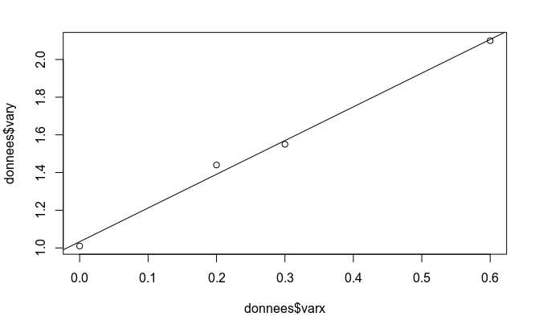

```r
plot(donnees$varx,donnees$vary)
abline(lm$coefficients[1],lm$coefficients[2])
```

Question 3

voir plus d’infos sur la regression

```r
data_sum
```

```
Call:
lm(formula = vary ~ varx, data = donnees)

Residuals:
        1         2         3         4
-0.022933  0.049200 -0.019733 -0.006533

Coefficients:
            Estimate Std. Error t value Pr(>|t|)
(Intercept)  1.03293    0.03322   31.09  0.00103 **
varx         1.78933    0.09492   18.85  0.00280 **
---
Signif. codes:  0 ‘***’ 0.001 ‘**’ 0.01 ‘*’ 0.05 ‘.’ 0.1 ‘ ’ 1

Residual standard error: 0.0411 on 2 degrees of freedom
Multiple R-squared:  0.9944,    Adjusted R-squared:  0.9916
F-statistic: 355.4 on 1 and 2 DF,  p-value: 0.002802
```

On peut vérifier que la somme des résidus fait 0

```r
sum(data_sum$residuals)
```

```
[1] 0
```

On peut aussi vérifier que x_*b+a=y_

```r
mean(donnees$varx)*lm$coefficients[2]+lm$coefficients[1]
```

```
 varx
1.525
```

```r
mean(donnees$vary)
```

```
[1] 1.525
```

Question 4

soit la variance empirique de l’echantillon Y

```r
length(donnees$vary)
```

```
[1] 4
```

```r
SY2
```

```
[1] 0.150925
```

La variance expliquée par le régression Sres= mean((Yi^-Y_)**2) lm$fitted.value est le Y^i

```r
(Sreg <- mean((lm$fitted.values - mean(donnees$vary))^2))
```

```
[1] 0.1500803
```

Et la variance résiduelle Sres = mean((Yi-Y^i)**2) est

```r
Sres
```

```
[1] 0.0008446667
```

Question 5

Coeff de détermination r**2 = Sreg/SY2 =coeff pearson entre x et y au carre vérification

```r
Sreg/SY2
```

```
[1] 0.9944034
```

ou bien

```r
data_sum$r.squared
```

```
[1] 0.9944034
```

ou bien

```r
cor(donnees$varx, donnees$vary, method = "pearson")^2
```

```
[1] 0.9944034
```

Evalutaion visuellement la normalité des résidus à l’aide d’un diagramme quantile–quantile avec des fonctions qqnorm et qqline.

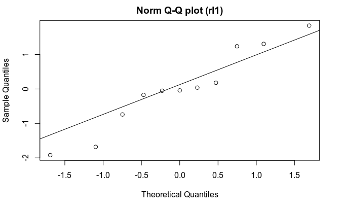

Plot pour montrer les résidus en fonction des prévisions

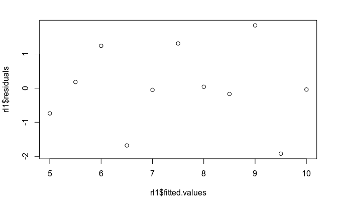

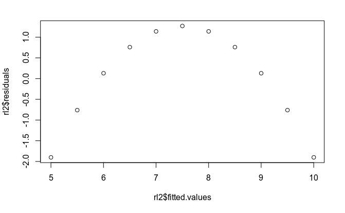

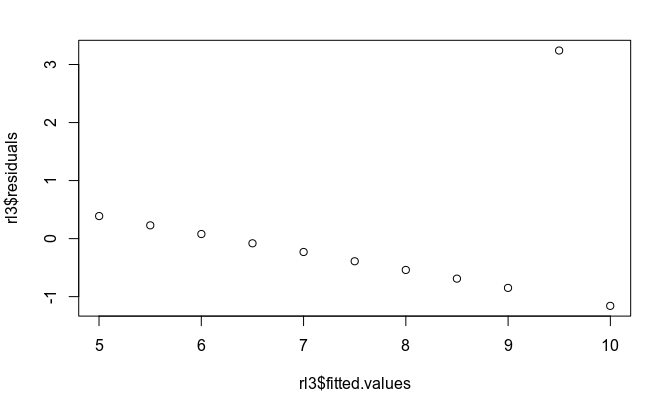

```r
plot(rl1$fitted.values,rl1$residuals)
plot(rl2$fitted.values,rl2$residuals)

plot(rl3$fitted.values,rl3$residuals)
```

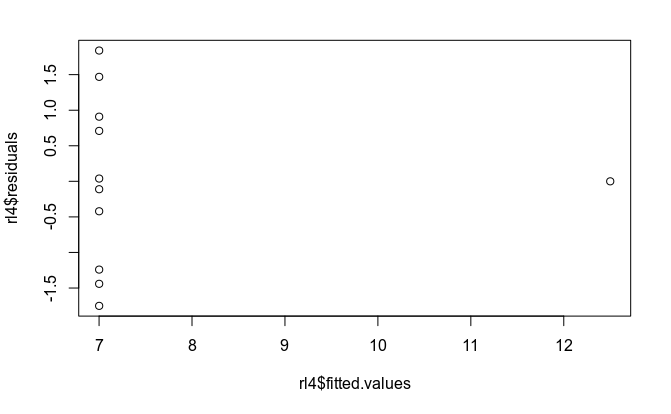

```r
plot(rl4$fitted.values,rl4$residuals)
```

2 Prédiciton

```r
rl=lm(Pression ~ Temp, data = hooker.data)
summary(rl)
```

```
Call:
lm(formula = Pression ~ Temp, data = hooker.data)

Residuals:
      Min        1Q    Median        3Q       Max
-0.020515 -0.008344 -0.003316  0.008811  0.027148

Coefficients:
              Estimate Std. Error t value Pr(>|t|)
(Intercept) -1.6818693  0.0398122  -42.24   <2e-16 ***
Temp         0.0264864  0.0004478   59.14   <2e-16 ***
---
Signif. codes:  0 ‘***’ 0.001 ‘**’ 0.01 ‘*’ 0.05 ‘.’ 0.1 ‘ ’ 1

Residual standard error: 0.01191 on 29 degrees of freedom
Multiple R-squared:  0.9918,    Adjusted R-squared:  0.9915
F-statistic:  3498 on 1 and 29 DF,  p-value: < 2.2e-16
```

Question 10

donner un intervalle de confiance sur les coeffs de la régression lineaire aka droite des mondres carres

```r
confint(rl,level=0.99)
```

```
                  0.5 %     99.5 %
(Intercept) -1.79160707 -1.5721316
Temp         0.02525198  0.0277208
```

On veut utiliser la fonction prédict pour prédire la pression a partir d’une mesure de temp

```r
predict(rl,newdata, interval = "confidence")
```

```
        fit       lwr       upr
1 0.8873108 0.8785957 0.8960259
```

3 Etude de la loi de MOORE

```r
summary(rl.moore)
```

```
Call:
lm(formula = log(Transistor.count) ~ Date.of.introduction, data = moore.data)

Residuals:
    Min      1Q  Median      3Q     Max
-5.1301 -0.3279  0.1730  0.5220  2.0624

Coefficients:
                       Estimate Std. Error t value Pr(>|t|)
(Intercept)          -681.23873   15.75785  -43.23   <2e-16 ***
Date.of.introduction    0.34917    0.00788   44.31   <2e-16 ***
---
Signif. codes:  0 ‘***’ 0.001 ‘**’ 0.01 ‘*’ 0.05 ‘.’ 0.1 ‘ ’ 1

Residual standard error: 1.049 on 100 degrees of freedom
Multiple R-squared:  0.9515,    Adjusted R-squared:  0.9511
F-statistic:  1963 on 1 and 100 DF,  p-value: < 2.2e-16
```

```r
(IC <- confint(rl.moore, "Date.of.introduction"))
```

```
                         2.5 %    97.5 %
Date.of.introduction 0.3335336 0.3648017
```

Pour prédire count en fonction de date of introduction interval =“confidence” pour tenir compte de l’incertitude sur x puis sur y

```r
exp(predict(rl.moore, newdata = data.frame(Date.of.introduction = 2018), interval ="confidence"))
```

```
          fit         lwr         upr
1 14271405422 10022931160 20320703543
```

```r
exp(predict(rl.moore, newdata = data.frame(Date.of.introduction = 2018), interval ="confidence"))
```

```
          fit         lwr         upr
1 14271405422 10022931160 20320703543
```

Pour trouver la période de doublage:

```r
log(2)/IC
```

```
                        2.5 %   97.5 %
Date.of.introduction 2.078193 1.900066
```

Correspondant à 2 ans